# Project: NICS Firearm Background Check Data

- Introduction
- Data Wrangling
- Exploratory Data Analysis
- Conclusions

## Introduction

### Dataset Description

The first two columns in this table give the month and state, which is important for tracking *when* and *where* these checks happened. Next, there are two columns that give the number of checks performed for a Permit or Permit Recheck. Following these, there are three columns that represent the number of checks for each *type* of firearm. As defined by the Bureau of Alcohol, Tobacco, Firearms and Explosives, a firearm can be a Hangun, a Long Gun, or Other. The "Multiple" column is used to describe a single background check associated with *multiple* types of firearms. The "Admin" column tracks the number of checks performed for administrative reasons. After this, there is a column for each *firearm type* within each *transaction type*. These transactions include: Pre-Pawn, Redemption, Returned/Disposition, Rentals, Private Sale, and Return to Seller-Private Sale. Finally, there is a "Totals" column which gives the total amount of checks performed across all the previous categories.

In order to investigate this data on a deeper level, supplementary data has been provided from census.gov. This set includes state level census data from either a single year (2016) or measuring across several years. There are 52 columns of data within this table. The first column, "Fact", notes the piece of census data that is being measured. "Fact Note", the next column, gives further context to a few of the Facts. The rest of the 50 columns represent the 50 United States, which contain data for each of the given Facts.

Given these two tables, it is possible to investigate relationships between census data and NICS background checks for each state in the United States.

### Questions for Analysis

The questions I am interested in exploring are as follows:

> 1. Which states have had the highest growth in gun registrations?
> 2. What census data is most associated with high gun per capita?

### Import statements

```python
# Importing NumPy and Pandas to work with

import numpy as np
import pandas as pd

# Import seaborn to use for scatter plots later on
import seaborn.objects as so

# Define a function that sets axis labels and title for a given plot
# Default font size is 8, but can be overriden
def set_labels(plot, x, y, title, size=8):
    plot.set_xlabel(x, fontsize=size)
    plot.set_ylabel(y, fontsize=size)
    plot.set_title(title, fontsize=size);
```

## Data Wrangling

### Data Assessment

Here, I will load in my datasets and explore their general properties. This will help to familiarize myself with the data and get a sense of what steps I will need to take when performing data cleaning.

#### FBI Gun Background Check Data

I will begin with the dataset containing information about NCIS gun background checks.

```python
# Read in dataset and look at the number of rows and columns

df_guns = pd.read_csv('Database_Ncis_and_Census_data/gun_data.csv')
df_guns.shape
```

```
(12485, 27)
```

```python
# Look at the head to see what the table looks like

df_guns.head()
```

|  | month | state | permit | permit_recheck | handgun | long_gun | other | multiple | admin | prepawn_handgun | ... | returned_other | rentals_handgun | rentals_long_gun | private_sale_handgun | private_sale_long_gun | private_sale_other | return_to_seller_handgun | return_to_seller_long_gun | return_to_seller_other | totals |
| --- | --- | --- | --- | --- | --- | --- | --- | --- | --- | --- | --- | --- | --- | --- | --- | --- | --- | --- | --- | --- | --- |
| 0 | 2017-09 | Alabama | 16717.0 | 0.0 | 5734.0 | 6320.0 | 221.0 | 317 | 0.0 | 15.0 | ... | 0.0 | 0.0 | 0.0 | 9.0 | 16.0 | 3.0 | 0.0 | 0.0 | 3.0 | 32019 |
| 1 | 2017-09 | Alaska | 209.0 | 2.0 | 2320.0 | 2930.0 | 219.0 | 160 | 0.0 | 5.0 | ... | 0.0 | 0.0 | 0.0 | 17.0 | 24.0 | 1.0 | 0.0 | 0.0 | 0.0 | 6303 |
| 2 | 2017-09 | Arizona | 5069.0 | 382.0 | 11063.0 | 7946.0 | 920.0 | 631 | 0.0 | 13.0 | ... | 0.0 | 0.0 | 0.0 | 38.0 | 12.0 | 2.0 | 0.0 | 0.0 | 0.0 | 28394 |
| 3 | 2017-09 | Arkansas | 2935.0 | 632.0 | 4347.0 | 6063.0 | 165.0 | 366 | 51.0 | 12.0 | ... | 0.0 | 0.0 | 0.0 | 13.0 | 23.0 | 0.0 | 0.0 | 2.0 | 1.0 | 17747 |
| 4 | 2017-09 | California | 57839.0 | 0.0 | 37165.0 | 24581.0 | 2984.0 | 0 | 0.0 | 0.0 | ... | 0.0 | 0.0 | 0.0 | 0.0 | 0.0 | 0.0 | 0.0 | 0.0 | 0.0 | 123506 |

5 rows × 27 columns

```python
# Use the describe method to see some of the descriptive statistics for
#    this dataset

df_guns.describe()
```

|  | permit | permit_recheck | handgun | long_gun | other | multiple | admin | prepawn_handgun | prepawn_long_gun | prepawn_other | ... | returned_other | rentals_handgun | rentals_long_gun | private_sale_handgun | private_sale_long_gun | private_sale_other | return_to_seller_handgun | return_to_seller_long_gun | return_to_seller_other | totals |
| --- | --- | --- | --- | --- | --- | --- | --- | --- | --- | --- | --- | --- | --- | --- | --- | --- | --- | --- | --- | --- | --- |
| count | 12461.000000 | 1100.000000 | 12465.000000 | 12466.000000 | 5500.000000 | 12485.000000 | 12462.000000 | 10542.000000 | 10540.000000 | 5115.000000 | ... | 1815.000000 | 990.000000 | 825.000000 | 2750.000000 | 2750.000000 | 2750.000000 | 2475.000000 | 2750.000000 | 2255.000000 | 12485.000000 |
| mean | 6413.629404 | 1165.956364 | 5940.881107 | 7810.847585 | 360.471636 | 268.603364 | 58.898090 | 4.828021 | 7.834156 | 0.165591 | ... | 1.027548 | 0.076768 | 0.087273 | 14.936000 | 11.602909 | 1.030182 | 0.402020 | 0.441818 | 0.105987 | 21595.725911 |
| std | 23752.338269 | 9224.200609 | 8618.584060 | 9309.846140 | 1349.478273 | 783.185073 | 604.814818 | 10.907756 | 16.468028 | 1.057105 | ... | 4.386296 | 0.634503 | 0.671649 | 71.216021 | 54.253090 | 4.467843 | 1.446568 | 1.528223 | 0.427363 | 32591.418387 |
| min | 0.000000 | 0.000000 | 0.000000 | 0.000000 | 0.000000 | 0.000000 | 0.000000 | 0.000000 | 0.000000 | 0.000000 | ... | 0.000000 | 0.000000 | 0.000000 | 0.000000 | 0.000000 | 0.000000 | 0.000000 | 0.000000 | 0.000000 | 0.000000 |
| 25% | 0.000000 | 0.000000 | 865.000000 | 2078.250000 | 17.000000 | 15.000000 | 0.000000 | 0.000000 | 0.000000 | 0.000000 | ... | 0.000000 | 0.000000 | 0.000000 | 0.000000 | 0.000000 | 0.000000 | 0.000000 | 0.000000 | 0.000000 | 4638.000000 |
| 50% | 518.000000 | 0.000000 | 3059.000000 | 5122.000000 | 121.000000 | 125.000000 | 0.000000 | 0.000000 | 1.000000 | 0.000000 | ... | 0.000000 | 0.000000 | 0.000000 | 0.000000 | 0.000000 | 0.000000 | 0.000000 | 0.000000 | 0.000000 | 12399.000000 |
| 75% | 4272.000000 | 0.000000 | 7280.000000 | 10380.750000 | 354.000000 | 301.000000 | 0.000000 | 5.000000 | 8.000000 | 0.000000 | ... | 0.000000 | 0.000000 | 0.000000 | 2.000000 | 4.000000 | 0.000000 | 0.000000 | 0.000000 | 0.000000 | 25453.000000 |
| max | 522188.000000 | 116681.000000 | 107224.000000 | 108058.000000 | 77929.000000 | 38907.000000 | 28083.000000 | 164.000000 | 269.000000 | 49.000000 | ... | 64.000000 | 12.000000 | 12.000000 | 1017.000000 | 777.000000 | 71.000000 | 28.000000 | 17.000000 | 4.000000 | 541978.000000 |

8 rows × 25 columns

```python
# Use the info method to see data types and number of non-null values
#    in each column

df_guns.info()
```

```
<class 'pandas.core.frame.DataFrame'>
RangeIndex: 12485 entries, 0 to 12484
Data columns (total 27 columns):
 #   Column                     Non-Null Count  Dtype
---  ------                     --------------  -----
 0   month                      12485 non-null  object
 1   state                      12485 non-null  object
 2   permit                     12461 non-null  float64
 3   permit_recheck             1100 non-null   float64
 4   handgun                    12465 non-null  float64
 5   long_gun                   12466 non-null  float64
 6   other                      5500 non-null   float64
 7   multiple                   12485 non-null  int64
 8   admin                      12462 non-null  float64
 9   prepawn_handgun            10542 non-null  float64
```

[output cut: 19 more lines]

```python
# I am interested to see what our values are in the 'month' column.
#    Where does the data start and end?

df_guns['month'].unique()
```

```
array(['2017-09', '2017-08', '2017-07', '2017-06', '2017-05', '2017-04',
       '2017-03', '2017-02', '2017-01', '2016-12', '2016-11', '2016-10',
       '2016-09', '2016-08', '2016-07', '2016-06', '2016-05', '2016-04',
       '2016-03', '2016-02', '2016-01', '2015-12', '2015-11', '2015-10',
       '2015-09', '2015-08', '2015-07', '2015-06', '2015-05', '2015-04',
       '2015-03', '2015-02', '2015-01', '2014-12', '2014-11', '2014-10',
       '2014-09', '2014-08', '2014-07', '2014-06', '2014-05', '2014-04',
       '2014-03', '2014-02', '2014-01', '2013-12', '2013-11', '2013-10',
       '2013-09', '2013-08', '2013-07', '2013-06', '2013-05', '2013-04',
       '2013-03', '2013-02', '2013-01', '2012-12', '2012-11', '2012-10',
       '2012-09', '2012-08', '2012-07', '2012-06', '2012-05', '2012-04',
       '2012-03', '2012-02', '2012-01', '2011-12', '2011-11', '2011-10',
       '2011-09', '2011-08', '2011-07', '2011-06', '2011-05', '2011-04',
       '2011-03', '2011-02', '2011-01', '2010-12', '2010-11', '2010-10',
       '2010-09', '2010-08', '2010-07', '2010-06', '2010-05', '2010-04',
       '2010-03', '2010-02', '2010-01', '2009-12', '2009-11', '2009-10',
       '2009-09', '2009-08', '2009-07', '2009-06', '2009-05', '2009-04',
       '2009-03', '2009-02', '2009-01', '2008-12', '2008-11', '2008-10',
       '2008-09', '2008-08', '2008-07', '2008-06', '2008-05', '2008-04',
       '2008-03', '2008-02', '2008-01', '2007-12', '2007-11', '2007-10',
       '2007-09', '2007-08', '2007-07', '2007-06', '2007-05', '2007-04',
       '2007-03', '2007-02', '2007-01', '2006-12', '2006-11', '2006-10',
       '2006-09', '2006-08', '2006-07', '2006-06', '2006-05', '2006-04',
       '2006-03', '2006-02', '2006-01', '2005-12', '2005-11', '2005-10',
       '2005-09', '2005-08', '2005-07', '2005-06', '2005-05', '2005-04',
       '2005-03', '2005-02', '2005-01', '2004-12', '2004-11', '2004-10',
       '2004-09', '2004-08', '2004-07', '2004-06', '2004-05', '2004-04',
       '2004-03', '2004-02', '2004-01', '2003-12', '2003-11', '2003-10',
       '2003-09', '2003-08', '2003-07', '2003-06', '2003-05', '2003-04',
       '2003-03', '2003-02', '2003-01', '2002-12', '2002-11', '2002-10',
       '2002-09', '2002-08', '2002-07', '2002-06', '2002-05', '2002-04',
       '2002-03', '2002-02', '2002-01', '2001-12', '2001-11', '2001-10',
       '2001-09', '2001-08', '2001-07', '2001-06', '2001-05', '2001-04',
       '2001-03', '2001-02', '2001-01', '2000-12', '2000-11', '2000-10',
       '2000-09', '2000-08', '2000-07', '2000-06', '2000-05', '2000-04',
       '2000-03', '2000-02', '2000-01', '1999-12', '1999-11', '1999-10',
       '1999-09', '1999-08', '1999-07', '1999-06', '1999-05', '1999-04',
       '1999-03', '1999-02', '1999-01', '1998-12', '1998-11'],
      dtype=object)
```

#### U.S. Census Data

Next, I will load in and investigate the U.S. Census Data.

```python
# Read in dataset and look at the number of rows and columns

df_census = pd.read_csv('Database_Ncis_and_Census_data/US_Census_Data.csv')
df_census.shape
```

```
(85, 52)
```

```python
# Take a look at the head of the data to see how our table is organized

df_census.head()
```

|  | Fact | Fact Note | Alabama | Alaska | Arizona | Arkansas | California | Colorado | Connecticut | Delaware | ... | South Dakota | Tennessee | Texas | Utah | Vermont | Virginia | Washington | West Virginia | Wisconsin | Wyoming |
| --- | --- | --- | --- | --- | --- | --- | --- | --- | --- | --- | --- | --- | --- | --- | --- | --- | --- | --- | --- | --- | --- |
| 0 | Population estimates, July 1, 2016, (V2016) | NaN | 4,863,300 | 741,894 | 6,931,071 | 2,988,248 | 39,250,017 | 5,540,545 | 3,576,452 | 952,065 | ... | 865454 | 6651194 | 27,862,596 | 3,051,217 | 624,594 | 8,411,808 | 7,288,000 | 1,831,102 | 5,778,708 | 585,501 |
| 1 | Population estimates base, April 1, 2010, (V2... | NaN | 4,780,131 | 710,249 | 6,392,301 | 2,916,025 | 37,254,522 | 5,029,324 | 3,574,114 | 897,936 | ... | 814195 | 6346298 | 25,146,100 | 2,763,888 | 625,741 | 8,001,041 | 6,724,545 | 1,853,011 | 5,687,289 | 563,767 |
| 2 | Population, percent change - April 1, 2010 (es... | NaN | 1.70% | 4.50% | 8.40% | 2.50% | 5.40% | 10.20% | 0.10% | 6.00% | ... | 0.063 | 0.048 | 10.80% | 10.40% | -0.20% | 5.10% | 8.40% | -1.20% | 1.60% | 3.90% |
| 3 | Population, Census, April 1, 2010 | NaN | 4,779,736 | 710,231 | 6,392,017 | 2,915,918 | 37,253,956 | 5,029,196 | 3,574,097 | 897,934 | ... | 814180 | 6346105 | 25,145,561 | 2,763,885 | 625,741 | 8,001,024 | 6,724,540 | 1,852,994 | 5,686,986 | 563,626 |
| 4 | Persons under 5 years, percent, July 1, 2016, ... | NaN | 6.00% | 7.30% | 6.30% | 6.40% | 6.30% | 6.10% | 5.20% | 5.80% | ... | 0.071 | 0.061 | 7.20% | 8.30% | 4.90% | 6.10% | 6.20% | 5.50% | 5.80% | 6.50% |

5 rows × 52 columns

```python
# Use the info method to see the data type for each column and non-null
#    counts

df_census.info()
```

```
<class 'pandas.core.frame.DataFrame'>
RangeIndex: 85 entries, 0 to 84
Data columns (total 52 columns):
 #   Column          Non-Null Count  Dtype
---  ------          --------------  -----
 0   Fact            80 non-null     object
 1   Fact Note       28 non-null     object
 2   Alabama         65 non-null     object
 3   Alaska          65 non-null     object
 4   Arizona         65 non-null     object
 5   Arkansas        65 non-null     object
 6   California      65 non-null     object
 7   Colorado        65 non-null     object
 8   Connecticut     65 non-null     object
 9   Delaware        65 non-null     object
```

[output cut: 44 more lines]

### Data Cleaning

Now that I better understand the data I will be working with, it is time to perform data cleaning to get it ready for exploration and analysis.

#### Gun Data

For the gun background check data, there are 27 columns and 12,485 rows. Most of that data is numerical, aside from the "month" and "state" columns. The data ranges from November 1998 to September 2017.

I will not be investigating how the *type* of background check affects my research questions, so I can drop those unnecessary columns. I will also need to create a new "year" column with newly calculated totals, as the data is currently organized by month.

```python
# Create new, clean dataset with only the columns we are interested in
# This new, clean, dataset has no null values

df_guns_clean = df_guns[['state', 'month', 'totals']].copy()

df_guns_clean.info()
```

```
<class 'pandas.core.frame.DataFrame'>
RangeIndex: 12485 entries, 0 to 12484
Data columns (total 3 columns):
 #   Column  Non-Null Count  Dtype
---  ------  --------------  -----
 0   state   12485 non-null  object
 1   month   12485 non-null  object
 2   totals  12485 non-null  int64
dtypes: int64(1), object(2)
memory usage: 292.7+ KB
```

```python
# In order to convert months to years, we first have to
#    convert month strings to datetime type
df_guns_clean['month'] = pd.to_datetime(df_guns_clean['month'])

# Next, we can use the groupby and resample methods to find
#    totals for each year by state
df_guns_clean = df_guns_clean.groupby('state').resample('Y', on='month').sum(numeric_only=True)
df_guns_clean.reset_index(inplace=True)
df_guns_clean.insert(1, 'year', df_guns_clean['month'].dt.year)
df_guns_clean.drop(columns='month', inplace=True)
```

```python
# Finally, we need to drop data from 1998 and 2017, as these are
#    incomplete years

df_guns_clean.drop(df_guns_clean[df_guns_clean['year'] == 1998].index, inplace=True)
df_guns_clean.drop(df_guns_clean[df_guns_clean['year'] == 2017].index, inplace=True)

# View the clean dataset
df_guns_clean.head()
```

|  | state | year | totals |
| --- | --- | --- | --- |
| 1 | Alabama | 1999 | 246756 |
| 2 | Alabama | 2000 | 221911 |
| 3 | Alabama | 2001 | 230187 |
| 4 | Alabama | 2002 | 221008 |
| 5 | Alabama | 2003 | 225479 |

#### Census Data

Looking at the census data, there are 52 columns and 85 rows. 50 of those columns are associated with the 50 states, and the other 2 tell us more information about the type of data in each row. The rows all contain different census data, organized by state.

The info method shows that there are 65 non-null values for each state, and from the table we can assume that the null values come from the value flags/other notes that are not included in the actual data. We can go ahead and remove this. I believe that for my research questions it would be more beneficial to have the "type of census data" labels as my columns, as this would also allow the census data to match up with how the gun data is formatted; This means I will have to transpose the data. Finally, I will need to fix the datatypes to better reflect the data contained in each column and fill any remaining null values with means.

```python
# Dropping Fact Note column, as this will not help with our questions
# dropping all NaNs since these pertain to irrelevant rows
#    (notes included with census data)

df_census_clean = df_census.drop(columns='Fact Note').copy()
df_census_clean.dropna(inplace=True)
```

```python
# Transpose columns and rows to make the data match up better with
#    our other data. I am setting the index to "Fact" so that these
#    values will be our new columns. Finally, I am resetting the index
#    so that it does not index over state names and it removes "Fact"
#    as the index label.

df_census_clean = df_census_clean.set_index('Fact').T.rename_axis(None, axis=1).reset_index()
df_census_clean.head()

# Rename state column to have proper label
df_census_clean.rename(columns={'index':'state'}, inplace=True)
```

```python
# Now that the table has just the information needed, I can fix the
#    datatypes for each column. Currently, everything is a string--
#    I want percents to be represented as floats, and integers as ints

for c in df_census_clean.columns[1:]:
    if 'percent' in c:
        # if the column label represents a percent, remove % symbol from values and change to type float
        df_census_clean[c] = df_census_clean[c].astype(str).str.replace('%', '').astype(float, errors='ignore')
    else:
        # if not a percent, take any commas out of the values and change to type int
        df_census_clean[c] = df_census_clean[c].astype(str).str.replace(',', '').astype(int, errors='ignore')


# Replace null values with the means
df_census_clean = df_census_clean.fillna(df_census_clean.mean(numeric_only=True))

# View the clean dataset
df_census_clean.head()
```

|  | state | Population estimates, July 1, 2016, (V2016) | Population estimates base, April 1, 2010, (V2016) | Population, percent change - April 1, 2010 (estimates base) to July 1, 2016, (V2016) | Population, Census, April 1, 2010 | Persons under 5 years, percent, July 1, 2016, (V2016) | Persons under 5 years, percent, April 1, 2010 | Persons under 18 years, percent, July 1, 2016, (V2016) | Persons under 18 years, percent, April 1, 2010 | Persons 65 years and over, percent, July 1, 2016, (V2016) | ... | All firms, 2012 | Men-owned firms, 2012 | Women-owned firms, 2012 | Minority-owned firms, 2012 | Nonminority-owned firms, 2012 | Veteran-owned firms, 2012 | Nonveteran-owned firms, 2012 | Population per square mile, 2010 | Land area in square miles, 2010 | FIPS Code |
| --- | --- | --- | --- | --- | --- | --- | --- | --- | --- | --- | --- | --- | --- | --- | --- | --- | --- | --- | --- | --- | --- |
| 0 | Alabama | 4863300 | 4780131 | 1.7 | 4779736 | 6.0 | 6.4 | 22.6 | 23.7 | 16.1 | ... | 374153 | 203604 | 137630 | 92219 | 272651 | 41943 | 316984 | 94.4 | 50645.33 | "01" |
| 1 | Alaska | 741894 | 710249 | 4.5 | 710231 | 7.3 | 7.6 | 25.2 | 26.4 | 10.4 | ... | 68032 | 35402 | 22141 | 13688 | 51147 | 7953 | 56091 | 1.2 | 570640.95 | "02" |
| 2 | Arizona | 6931071 | 6392301 | 8.4 | 6392017 | 6.3 | 7.1 | 23.5 | 25.5 | 16.9 | ... | 499926 | 245243 | 182425 | 135313 | 344981 | 46780 | 427582 | 56.3 | 113594.08 | "04" |
| 3 | Arkansas | 2988248 | 2916025 | 2.5 | 2915918 | 6.4 | 6.8 | 23.6 | 24.4 | 16.3 | ... | 231959 | 123158 | 75962 | 35982 | 189029 | 25915 | 192988 | 56 | 52035.48 | "05" |
| 4 | California | 39250017 | 37254522 | 5.4 | 37253956 | 6.3 | 6.8 | 23.2 | 25.0 | 13.6 | ... | 3548449 | 1852580 | 1320085 | 1619857 | 1819107 | 252377 | 3176341 | 239.1 | 155779.22 | "06" |

5 rows × 66 columns

## Exploratory Data Analysis

### 1. Which states have had the highest growth in gun registrations?

#### Highest total growth from 1999 to 2016

First, I want to identify which states had the highest growth in gun registrations overall. To do this, I will need to find the difference in registration totals from 1999 and 2016.

```python
# Create a new dataframe that will contain the growth in gun
#    registrations from 1999 to 2016 for each state
df_guns_growth = pd.DataFrame()

# Create a 'state' column with only the unique values in our clean
#    dataframe. (USing
df_guns_growth['state'] = df_guns_clean['state'].unique()

# Reset the index to make our table a bit easier to read
df_guns_growth.reset_index(inplace=True, drop=True)

# Iterate through the columns and create a row in the new dataframe
#    that contains the change from the value in 1999 to the value
#    in 2016.
#    Note: Pandas will automatically match indeces when calculating
#    the difference, so I am using reset_index to ensure the indeces
#    from each query match up
df_guns_growth['growth'] = df_guns_clean.query('year==2016').reset_index()['totals'] - df_guns_clean.query('year==1999').reset_index()['totals']

# View this new dataset
df_guns_growth.describe()
```

|  | growth |
| --- | --- |
| count | 5.500000e+01 |
| mean | 3.342139e+05 |
| std | 5.550837e+05 |
| min | -3.400000e+01 |
| 25% | 6.386600e+04 |
| 50% | 1.643500e+05 |
| 75% | 3.450030e+05 |
| max | 3.428635e+06 |

```python
# I am interested in states with highest total growth
#    (I chose to select states with growth higher than the 90th quantile, as this narrows down the
#    pool to the top 6)
df_guns_high = df_guns_growth[df_guns_growth['growth'] > df_guns_growth['growth'].quantile(0.90)]

# Assigning this new dataframe to a filtered version of the clean data
#    containing only the states determined to have the highest growth
df_guns_high = df_guns_clean[df_guns_clean['state'].isin(df_guns_high['state'])]

# View all states in this new dataset
df_guns_high['state'].unique()
```

```
array(['California', 'Florida', 'Illinois', 'Indiana', 'Kentucky',
       'Texas'], dtype=object)
```

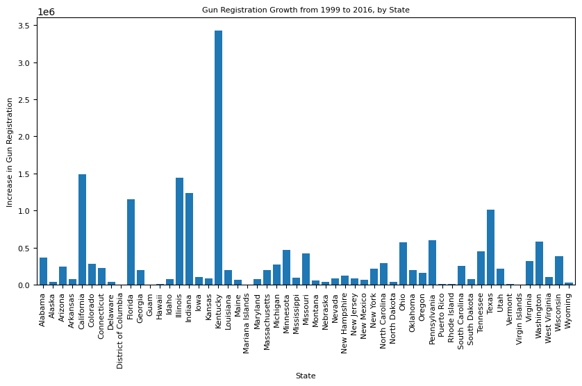

```python
# Create graph plotting states against total growth
plot1 = df_guns_growth.plot(x='state', y='growth', kind='bar', width=0.8, fontsize=8, figsize=(10,5), legend=False, title='Gun Registration Growth from 1999 to 2016, by State')
set_labels(plot1, 'State', 'Increase in Gun Registration', 'Gun Registration Growth from 1999 to 2016, by State');
```

This graph illustrates the growth in gun registrations from 1999 to 2016 for each state. It is extremely clear that Kentucky had the highest growth in that timeframe, and we can see a few other states with high growth as well.

#### Growth in registrations by year

Now that I have determined the states with the highest total growth in gun registrations, I am interested in what that growth actually looked like. To find this out, I will create a graph showing the growth in registrations by year for each of the states with highest growth.

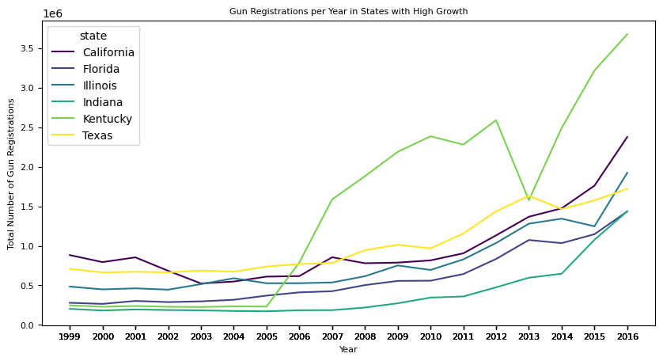

```python
# Creating a pivot table to set year column against totals column,
#    adding a new line for each state
plot2 = pd.pivot_table(df_guns_high.set_index('year'),values='totals', index=['year'],columns=['state'])

# Creating a plot from the new pivot table and tweaking attributes for
#    better readability
plot2 = plot2.plot(colormap='viridis', figsize=(10, 5), xticks=df_guns_high['year'], fontsize=8);
set_labels(plot2,'Year', 'Total Number of Gun Registrations', 'Gun Registrations per Year in States with High Growth');
```

This graph shows the growth of gun registrations per year in states determined to have high overall growth. We can see a general upward trend across all of these states during the timeframe. Interestingly, there appears to be a period of rapid growth from about 2014 to 2016.

### 2. What census data is most associated with high gun per capita?

#### Finding guns per capita

In order to answer this question, we first need to find the gun per capita value for each state. To do this, I will need to find the quotient of gun registration totals and state population. Once I have the gun per capita value for each state, I can create a new dataframe holding states with the highest values.

```python
# Create new list that we will fill with our guns per capita values
guns_per_cap = []

# Iterate through the rows in our census data and calculate guns per capita (2016)
for r in range(len(df_census_clean)):
    # Find gun total from gun dataframe that matches the current state in census
    #    dataframe and is from the year 2016
    guns = df_guns_clean.loc[(df_guns_clean['state'] == df_census_clean.iloc[r]['state']) & (df_guns_clean['year'] == 2016)]['totals'].item()
    # Calculate guns per capita by dividing gun totals by population in 2016
    #    and add this value to our list
    guns_per_cap.append(guns / df_census_clean.iloc[:, 1][r])

# Assign our list to a new column in the dataframe
df_census_clean['gun per capita'] = guns_per_cap

# View descriptive statistics for this new column
df_census_clean['gun per capita'].describe()
```

```
count    50.000000
mean      0.097695
std       0.111928
min       0.011677
25%       0.060872
50%       0.083753
75%       0.102326
max       0.828683
Name: gun per capita, dtype: float64
```

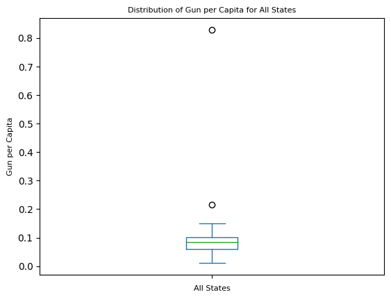

```python
# The max value is much larger than the mean; We can create a boxplot to view the distribution
#    and any outliers
boxplot = df_census_clean['gun per capita'].plot.box()
boxplot.set_xticklabels([])
set_labels(boxplot, 'All States', 'Gun per Capita', 'Distribution of Gun per Capita for All States');
```

This boxplot shows the distribution of gun per capita value for each state. While there appears to be 2 outliers, the values are not unreasonable for 'gun per capita' so they do not need to be removed.

```python
# find states with 'guns per capita' value larger than the mean to see which states have highest
#    guns per capita. (I chose to select states with gun per capita higher than the 90th quantile,
#    as this narrows down the pool to the top 5)
df_census_high = df_census_clean[df_census_clean['gun per capita'] > df_census_clean['gun per capita'].quantile(0.90)]
df_census_high[['state', 'gun per capita']]
```

|  | state | gun per capita |
| --- | --- | --- |
| 12 | Illinois | 0.150300 |
| 13 | Indiana | 0.216601 |
| 16 | Kentucky | 0.828683 |
| 25 | Montana | 0.130776 |
| 47 | West Virginia | 0.132352 |

#### Examine correlation between high gun per capita and other data

Now that we have calculated the gun per capita value for each state and identified those with the highest values, we can examine which pieces of census data are most associated. To do this, I will calculate the correlation coefficient.

```python
# Create a new dataframe that stores the correlation coefficient of guns per
#    capita against other census data (ignoring the last row, which is a self
#    comparison)
df_assoc = pd.DataFrame(df_census_high.corr(numeric_only=True)['gun per capita'][:-2])
df_assoc.rename_axis('census data', inplace=True)
```

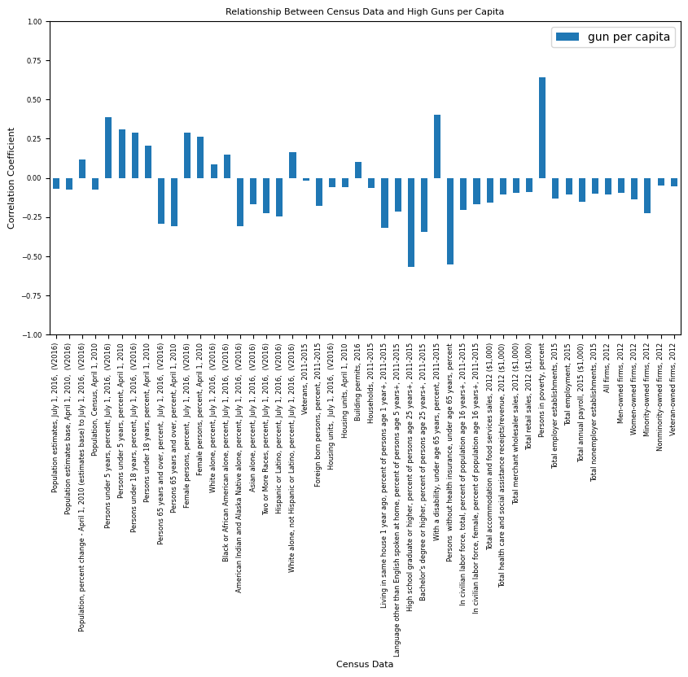

```python
# Create a bar graph showing the correlation for each piece of census data
# I set the y-axis range from -1 to 1, as this is the full possible range of correlation coefficients
assoc_plot = df_assoc.plot(kind='bar', figsize=(10, 5), fontsize=6)
assoc_plot.set_ylim(-1, 1)
set_labels(assoc_plot, 'Census Data', 'Correlation Coefficient', 'Relationship Between Census Data and High Guns per Capita');
```

While we can see that there are no strong correlations, there are a few pieces of census data that appear to be moderately correlated to gun per capita. Below, I will examine these relationships further.

```python
# Create list of columns we are interested in; This includes the columns with
#    a correlation coefficient larger than 0.5 (or smaller than -0.5), as these
#    indicate at least moderate strength
cols_to_keep = (df_assoc['gun per capita'][df_assoc['gun per capita'].abs() > 0.5]).index.tolist()
# We also want to keep the gun per capita column
cols_to_keep.append('gun per capita')

# Create a new dataframe using our list of columns to keep
df_census_corr = df_census_high[cols_to_keep]

# Create scatterplots to for each of these columns to see a visual representation
#    of the relationships (below)
```

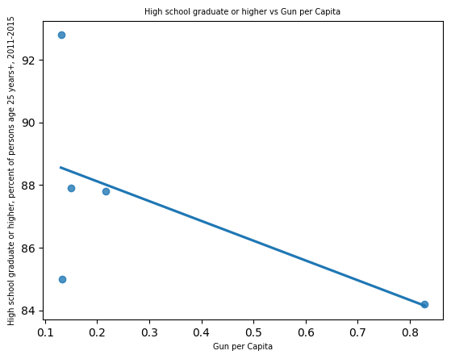

```python
plot = sns.regplot(df_census_corr, x='gun per capita', y=cols_to_keep[0], ci=None);
simple_label = cols_to_keep[0].split(',')[0]
set_labels(plot, 'Gun per Capita', cols_to_keep[0], simple_label + " vs Gun per Capita", 7)
```

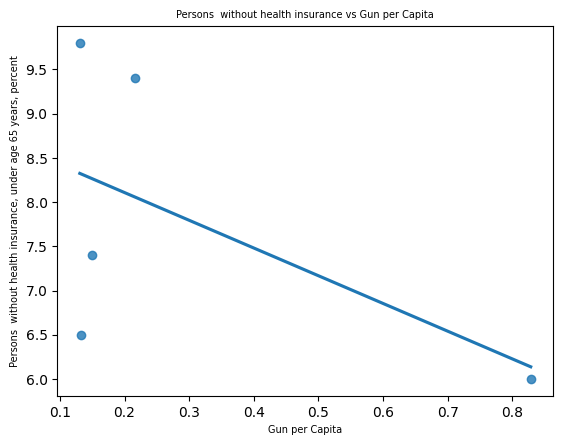

```python
plot = sns.regplot(df_census_corr, x='gun per capita', y=cols_to_keep[1], ci=None);
simple_label = cols_to_keep[1].split(',')[0]
set_labels(plot, 'Gun per Capita', cols_to_keep[1], simple_label + " vs Gun per Capita", 7)
```

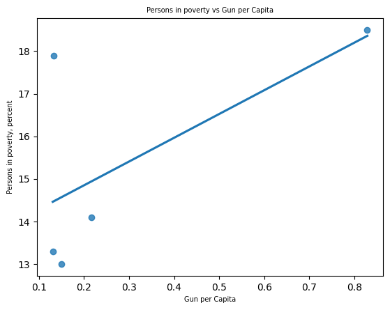

```python
plot = sns.regplot(df_census_corr, x='gun per capita', y=cols_to_keep[2], ci=None);
simple_label = cols_to_keep[2].split(',')[0]
set_labels(plot, 'Gun per Capita', cols_to_keep[2], simple_label + " vs Gun per Capita", 7)
```

In each of these scatter plots, we can see a linear trend among the data. However, the data points are not packed tightly along the trend line, so it cannot be said that any of these plots show a strong relationship.

## Conclusions

In comparing data from NICS firearm background checks and the United States census, several conclusions can be made.

It is important to note that one major limitation within this exploration is NICS firearm background checks do not have a one-to-one correlation with firearm sales. Any references to the aforementioned sales are merely an estimation, since the source material is not representative of the actual figures.

### 1. Which states have had the highest growth in gun registrations?

To find states with the highest growth in gun registrations I looked at the totals for each year, combining all types of firearms and all types of transactions. I created a bar graph to compare the growth between states, and there are a clear six states in the lead. In order of highest growth, these are: Kentucky, California, Illinois, Indiana, Florida, and Texas. Kentucky had the highest growth in gun registrations by far, with more than double that of the second-highest state.

Once I indentified states with the highest growth, I wanted to know more about what that growth actually *looked* like. To do this, I created a line graph for these six states that shows the totals for gun registrations by year, spanning 1999 to 2016. The graph shows a general trend of upward growth, with a period of higher growth from about 2014 to 2016. There is an opportunity here for further research, as it would be interesting to explore what caused this spike in gun registrations.

### 2. What census data is most associated with high gun per capita?

Before I could answer this question, I first had to find states with the highest gun per capita. I looked at gun totals for the year 2016 divided by the 2016 population for each state, and found that the top five were Kentucky, Indiana, Illinois, West Virginia, and Montana-- in that order. A box and whisker plot helped me see the distribution of gun per capita data; This brought my attention to two outliers. However, I was able to determine that the values represented by these outliers was within reasonable range, and I did not remove them from the dataset.

Next, I looked at correlation of census data and gun per capita values in these five states. I used a bar graph to compare the correlation coefficients for each piece of census data, limiting the y-axis range to the range of possibilities: -1 to 1. On this graph, three pieces of census data extend beyond a value of +/- 0.5 (This number is important, as it indicates at least a moderate relationship). These census categories are: high school graduates or higher (age 25+), persons without health insurance (under 65), and persons in poverty.

To better understand these relationships, I created a scatter plot for each census fact against gun per capita values. While a trend line can be seen, the data is not tightly packed around that line. Therefore, the correlation is only moderate at best.

Since high school graduates or higher (age 25+), persons without health insurance (under 65), and persons in poverty have the highest correlation to gun per capita value, it can be said that they are *most associated* with high gun per capita. However, since these correlations are not strong, we cannot confidently conclude that they are related. To get a more accurate picture of how this census data relates to high gun per capita, more reasearch is needed.

```python
# Running this cell will execute a bash command to convert this notebook to an .html file
!python -m nbconvert --to html Investigate_a_Dataset.ipynb
```

```
[NbConvertApp] Converting notebook Investigate_a_Dataset.ipynb to html
[NbConvertApp] WARNING | Alternative text is missing on 7 image(s).
[NbConvertApp] Writing 810348 bytes to Investigate_a_Dataset.html
```